# HW 8 - Bike Rentals

Annie Hou

04/23/2024

## Load packages and data

```r
library(tidyverse)
```

```r
dcbikeshare <- read_csv("data/bikeshare-day.csv", show_col_types = FALSE)
```

## Exercises

### Exercise 1

```r
dcbikeshare <- dcbikeshare %>%
  mutate(season = factor(season, levels = c(1, 2, 3, 4), labels = c("winter", "spring", "summer", "fall"))) %>%
  mutate(season = relevel(season, ref = "spring"))
```

### Exercise 2

```r
dcbikeshare <- dcbikeshare %>%
  mutate(weekday = case_when(
    weekday %in% 1:5 ~ "yes",
    weekday == 0 | weekday == 6 ~ "no"
  )) %>%
  mutate(holiday = factor(holiday, levels = c(0, 1), labels = c("no", "yes"))) %>%
  mutate(weekday = factor(weekday, levels = c("no", "yes")))
```

### Exercise 3

```r
dcbikeshare <- dcbikeshare %>%
  mutate(yr = factor(yr, levels = c(0, 1), labels = c("2011", "2012")))
```

### Exercise 4

```r
dcbikeshare <- dcbikeshare %>%
  mutate(weathersit = factor(weathersit, levels = c(1, 2, 3), labels = c("clear", "mist", "rain")))
```

### Exercise 5

```r
dcbikeshare <- dcbikeshare %>%
  mutate(raw_temp = temp * 41,
         raw_feel = atemp * 50,
         raw_hum = hum * 100,
         raw_windspeed = windspeed * 67)
```

### Exercise 6

```r
dcbikeshare <- dcbikeshare %>%
  mutate(check_sum = (casual + registered == cnt))

all_true <- all(dcbikeshare$check_sum)
print(all_true)
```

```
## [1] TRUE
```

### Exercise 7

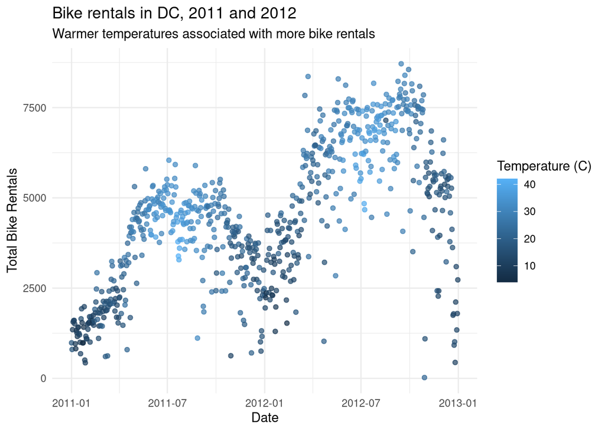

```r
ggplot(dcbikeshare, aes(x = dteday, y = cnt, color = raw_feel)) +
  geom_point(alpha = 0.7) +
  labs(x = "Date",
       y = "Total Bike Rentals",
       title = "Bike rentals in DC, 2011 and 2012",
       subtitle = "Warmer temperatures associated with more bike rentals",
       color = "Temperature (C)") +
  theme_minimal()
```

### Exercise 8

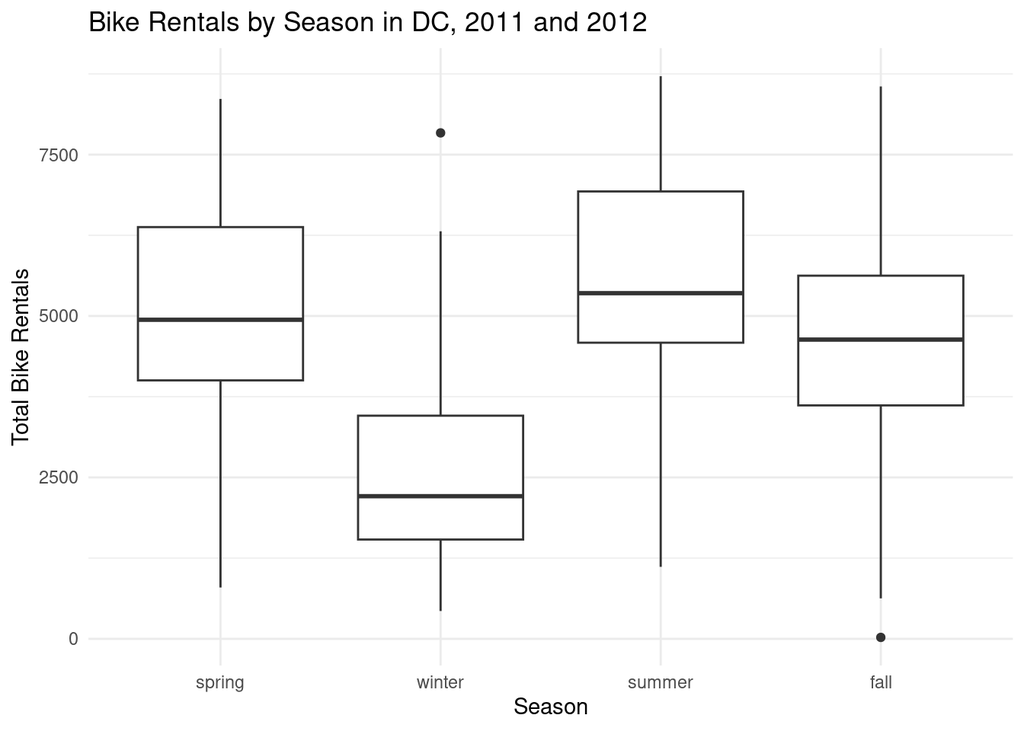

```r
ggplot(dcbikeshare, aes(x = season, y = cnt)) +
  geom_boxplot() +
  labs(title = "Bike Rentals by Season in DC, 2011 and 2012",
       x = "Season",
       y = "Total Bike Rentals") +
  theme_minimal()
```

I used a box plot here to show the relationship between bike rentals and season. The plot shows that number of bike rentals vary a lot with the seasons. Spring, summer, and fall have similar median values and interquartile ranges (where the range for summer is higher), which means that there are more demands especially during summer, and moderate number of rentals during spring and fall, given the weather is more likely to be warm and good. However, winter has a much lower median and interquartile range, which means that people don’t rent bike a lot in the winter, likely due to cold weather. The outlier in fall shows that there were days with unusually low rentals, which could be due to various factors like weather conditions or special events.

### Exercise 9

```r
model_temp <- lm(cnt ~ temp, data = dcbikeshare)
model_temp
```

```
##
## Call:
## lm(formula = cnt ~ temp, data = dcbikeshare)
##
## Coefficients:
## (Intercept)         temp
##        1215         6641
```

```r
summary(model_temp)$r.squared
```

```
## [1] 0.3937487
```

The linear model is: total daily bike rentals = 1215 + 6641*daily temperature

The R^2 value is around 0.3937, which means that around 39.37% of the variability in the total number of bike rentals can be explained by the daily temperature. It is relatively far from 1, meaning that the linear model doesn’t fit that well.

### Exercise 10

```r
model_atemp <- lm(cnt ~ atemp, data = dcbikeshare)
model_atemp
```

```
##
## Call:
## lm(formula = cnt ~ atemp, data = dcbikeshare)
##
## Coefficients:
## (Intercept)        atemp
##       945.8       7501.8
```

```r
summary(model_atemp)$r.squared
```

```
## [1] 0.3982439
```

The linear model is: total daily bike rentals = 945.8 + 7501.8*daily feeling temperature

The R^2 value is around 0.3982, which means that around 39.82% of the variability in the total number of bike rentals can be explained by the daily feeling temperature. Compare to the R^2 value for the daily temperature in the last problem, the R^2 increased slightly. It means that as a predictor of bike rentals, the feeling temperature is slightly better than temperature.

### Exercise 11

```r
model <- lm(cnt ~ season + yr + holiday + workingday + weathersit + atemp + hum + windspeed + atemp*holiday, data = dcbikeshare)
model
```

```
##
## Call:
## lm(formula = cnt ~ season + yr + holiday + workingday + weathersit +
##     atemp + hum + windspeed + atemp * holiday, data = dcbikeshare)
##
## Coefficients:
##      (Intercept)      seasonwinter      seasonsummer        seasonfall
##           2629.7           -1170.7            -195.8             375.0
##           yr2012        holidayyes        workingday    weathersitmist
##           2020.5           -1375.6             125.5            -419.2
##   weathersitrain             atemp               hum         windspeed
##          -1887.7            5435.3           -1376.0           -2494.4
## holidayyes:atemp
##           1758.1
```

```r
summary(model)$adj.r.squared
```

```
## [1] 0.8181315
```

The adjusted R squared here is around 0.818.

### Exercise 12

For non-holiday days, the fitted equation is: total daily bike rentals = (2629.7 + 0) -1170.7 * winter -195.8 * summer + 375.0 * fall + 2020.5 * yr + 125.5 * workingday - 419.2 * weather mist - 1887.7 * weather rain + 5435.3* feeling temperature - 1376.0 * humidity - 2494.4 * windspeed

For holiday days, the fitted equation is: total daily bike rentals = (2629.7 - 1375.6) -1170.7 * winter -195.8 * summer + 375.0 * fall + 2020.5 * yr + 125.5 * workingday - 419.2 * weather mist - 1887.7 * weather rain + (5435.3 + 1758.1) * feeling temperature - 1376.0 * humidity - 2494.4 * windspeed

### Exercise 13

The slope of season varies for different seasons, with the baseline being spring. The slope of summer is -195.8, meaning that on average summer has 195.8 units less total rentals compared to the rentals in spring. The slope of fall is 375.0, meaning that on average, fall has 375 units more than the rentals in spring. The slope of winter is -1170.7, meaning that on average, winter has 1170.7 units total rentals less than the rentals in spring.

The slope for the feeling temperature are different from holidays and non-holidays. The slope for holidays is 5435.3 + 1758.1= 7193.4, and the slope for non-holiday days is 5435.3.

### Exercise 14

The intercept for holidays (holiday = 1) is 2629.7 - 1375.6 = 1254.1, which means that if the feeling temperature and other variables were all zero, the total number of bike rentals on holiday would be 1254.1.

The intercept for non-holidays (holiday = 0) is 2629.7, which means that if the feeling temperature and other variables were all zero, the total number of bike rentals on non-holiday would be 2629.7.

### Exercise 15

The season with the highest predicted total daily bike rentals is fall, because it has the most positive coefficient (375.0), which means that on average it has the most increase in rentals compared to the baseline season spring, with everything else being the same.

The season with the lowest predicted total bike rentals is winter, because it has the most negative coefficient (-1170.7), which means that on average it has the least increase in rentals compared to the baseline season spring, with everything else being the same.